# PET575, Data Analysis in Python

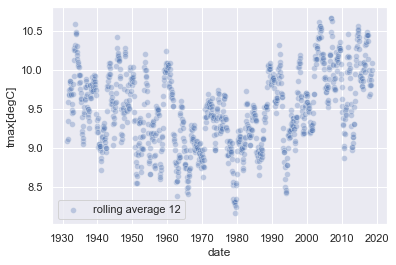

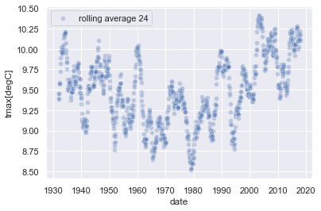

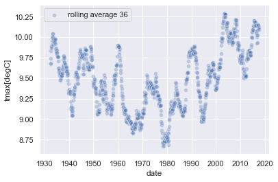

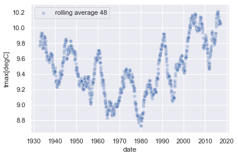

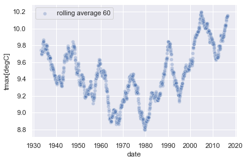

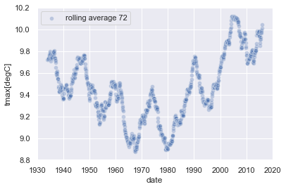

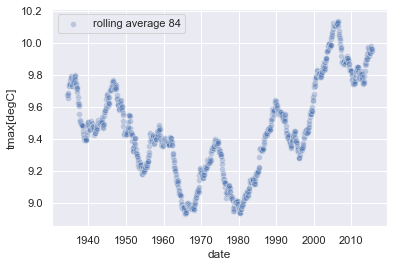

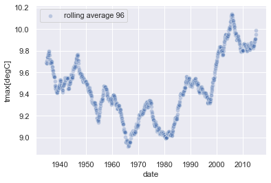

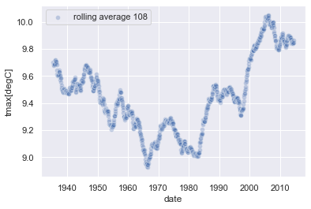

```python
for i in range(1,10):
    sns.scatterplot(df['date'],df['tmax[degC]'].rolling(12*i).mean(center=True),
                    alpha=0.3, label=f'rolling average {12*i}')
    plt.show()
```

This explains some articles from the 70s:

- U.S. Scientist Sees New Ice Age Coming (The Washington Post, July 9, 1971)
- Ice Age Around the Corner (Chicago Tribune, July 10, 1971)
- New Ice Age Coming – It’s Already Getting Colder (L.A. Times, October 24, 1971)

Pollution was likely driving factor in the cooling. Currently we somewhat *overcompensated* with CO2 emissions.

We can explore some correlations, like how is temperature related to rain?

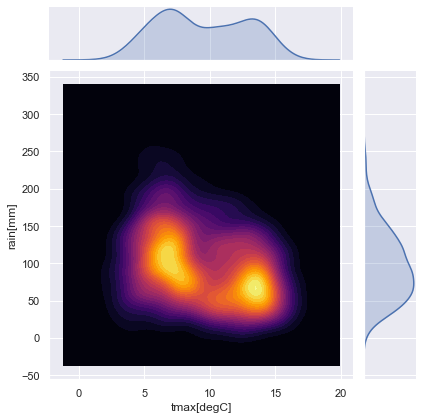

```python
x= df['tmax[degC]']
y= df['rain[mm]']
sns.jointplot(x, y, kind="kde", levels=25, cmap="inferno")
```

We can fairly easily plot LOWESS:

- **Lo**cally
- **We**ighted
- **S**catterplot
- **S**moothing

```python
from statsmodels.nonparametric.smoothers_lowess import lowess #import library that will do all the heavy lifting
y = df['tmax[degC]']
x = np.arange(0,len(df['date']),1) #converting into linear space from 0 to length of the dataset
w = lowess(y, x, frac=1/5)         #calculating LOWESS
                                   #frac is the window width in terms of a fraction of full width.
```

And let's plot the results. Some calculations on the *x* values to recover the year.

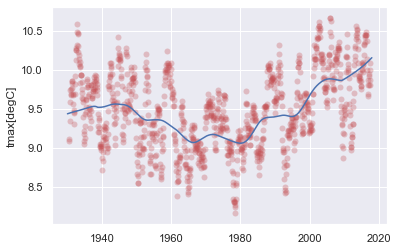

```python
sns.scatterplot(x/12+1930,y.rolling(12).mean(center=True),linewidth=0,color="r",alpha=0.3)
sns.lineplot(w[:,0]/12+1930,w[:,1])
```

We can explore how much smooting is too much smoothing

```
[]
```

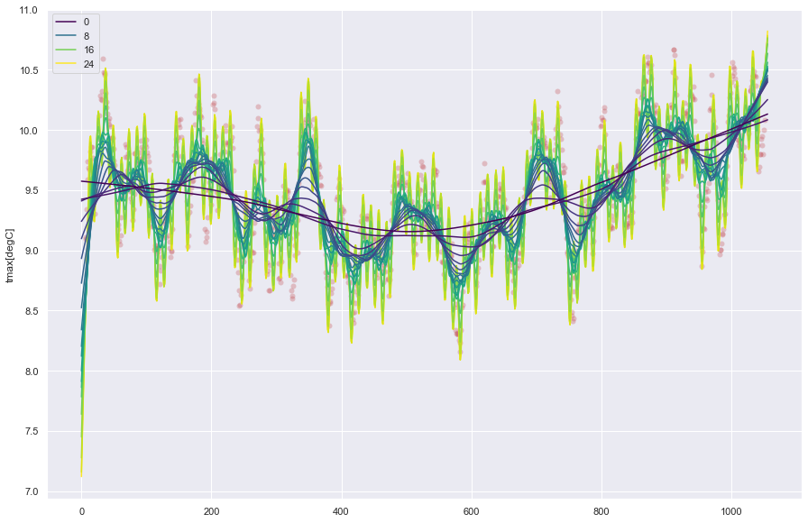

```python
plt.figure(figsize=(15,10)) # bigger plot for visibility

sns.scatterplot(x,y.rolling(12).mean(center=True),linewidth=0,color="r",alpha=0.3) #scatterplot for reference


for i in reversed(range(1,21)):  #note that reversed is used. This is to change the order of plotting of the charts.
    w = lowess(y, x, frac=1/(i*2))

    if i != 20:
        sns.lineplot(w[:,0],w[:,1], hue=i, palette='viridis',hue_norm=(1,20), legend=False)
    else:
        sns.lineplot(w[:,0],w[:,1], hue=i, palette='viridis',hue_norm=(1,20))

plt.plot()
```

Violin plots are often better than box plots, as they carry more data

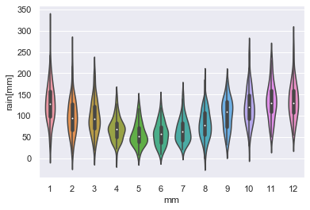

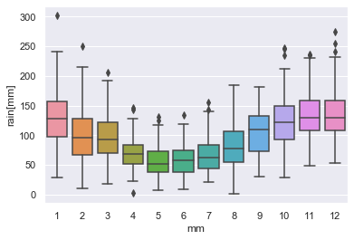

```python
x = df['rain[mm]']
y = df['mm']
sns.violinplot(y,x)
plt.show()
sns.boxplot(y,x)
```

### Real drilling data

Let's consider some real drilling data. We can import from web again, straight out of a zip file.

```python
df=pd.read_csv("http://www.ux.uis.no/~atunkiel/Norway-NA-15_$47$_9-F-9%20A%20depth.zip")
```

```python
list(df)
```

```
['Unnamed: 0',
 'Unnamed: 0.1',
 'Measured Depth m',
 'TOFB s',
 'AVG_CONF unitless',
 'MIN_CONF unitless',
 'Average Rotary Speed rpm',
 'STUCK_RT unitless',
 'Corrected Surface Weight on Bit kkgf',
 'Corrected Total Hookload kkgf',
 'MWD Turbine RPM rpm',
 'MWD Raw Gamma Ray 1/s',
 'MWD Continuous Inclination dega',
 'Pump 2 Stroke Rate 1/min',
 'Rate of Penetration m/h',
 'Bit Drill Time h',
 'Corrected Hookload kkgf',
 'MWD Gravity Toolface dega',
 'Mud Density Out g/cm3',
 'MWD GR Bit Confidence Flag %',
 'Pump Time h',
 'PowerUP Shock Rate 1/s',
 'Total SPM 1/min',
 'HKLO kkgf',
 'Average Hookload kkgf',
 'Total Hookload kkgf',
 'DRET unitless',
 'Extrapolated Hole TVD m',
 'MWD Gamma Ray (API BH corrected) gAPI',
 'Pump 1 Strokes unitless',
 'ROPIH s/m',
 'EDRT unitless',
 'Pump 1 Stroke Rate 1/min',
 'Rate of penetration m/h',
 'Iso-butane (IC4) ppm',
 'Bit Drilling Run m',
 'MWD Total Shocks unitless',
 'Total Bit Revolutions unitless',
 'Nor-butane (NC4) ppm',
 'Lag Depth (TVD) m',
```

[output cut: 60 more lines]

```
 'OSTM s',
 'nameWellbore',
 'name',
 'IMP/ARC Attenuation Conductivity 40-in. at 2 MHz mS/m',
 'ARC Annular Pressure kPa',
 'MWD Collar RPM rpm',
 'IMP/ARC Non-BHcorr Phase-Shift Resistivity 28-in. at 2 MHz ohm.m',
 'IMP/ARC Phase-Shift Conductivity 40-in. at 2 MHz mS/m',
 'Annular Temperature degC',
 'IMP/ARC Non-BHcorr Phase-Shift Resistivity 40-in. at 2 MHz ohm.m',
 'ARC Gamma Ray (BH corrected) gAPI',
 'IMP/ARC Non-BHcorr Attenuation Resistivity 40-in. at 2 MHz ohm.m',
 'MWD Stick-Slip PKtoPK RPM rpm',
 'IMP/ARC Non-BHcorr Attenuation Resistivity 28-in. at 2 MHz ohm.m',
 'IMP/ARC Phase-Shift Conductivity 28-in. at 2 MHz mS/m']
```

Verify the contents of the DataFrame. Note that real-life datasets can be overrun with NaNs.

```python
df.head()
```

|  | Unnamed: 0 | Unnamed: 0.1 | Measured Depth m | TOFB s | AVG_CONF unitless | MIN_CONF unitless | Average Rotary Speed rpm | STUCK_RT unitless | Corrected Surface Weight on Bit kkgf | Corrected Total Hookload kkgf | ... | MWD Collar RPM rpm | IMP/ARC Non-BHcorr Phase-Shift Resistivity 28-in. at 2 MHz ohm.m | IMP/ARC Phase-Shift Conductivity 40-in. at 2 MHz mS/m | Annular Temperature degC | IMP/ARC Non-BHcorr Phase-Shift Resistivity 40-in. at 2 MHz ohm.m | ARC Gamma Ray (BH corrected) gAPI | IMP/ARC Non-BHcorr Attenuation Resistivity 40-in. at 2 MHz ohm.m | MWD Stick-Slip PKtoPK RPM rpm | IMP/ARC Non-BHcorr Attenuation Resistivity 28-in. at 2 MHz ohm.m | IMP/ARC Phase-Shift Conductivity 28-in. at 2 MHz mS/m |
| --- | --- | --- | --- | --- | --- | --- | --- | --- | --- | --- | --- | --- | --- | --- | --- | --- | --- | --- | --- | --- | --- |
| 0 | 0 | 0 | 273.101 | NaN | NaN | NaN | NaN | NaN | NaN | NaN | ... | NaN | NaN | NaN | NaN | NaN | NaN | NaN | NaN | NaN | NaN |
| 1 | 1 | 1 | 273.253 | NaN | NaN | NaN | NaN | NaN | NaN | NaN | ... | NaN | NaN | NaN | NaN | NaN | NaN | NaN | NaN | NaN | NaN |
| 2 | 2 | 2 | 273.406 | NaN | NaN | NaN | NaN | NaN | NaN | NaN | ... | NaN | NaN | NaN | NaN | NaN | NaN | NaN | NaN | NaN | NaN |
| 3 | 3 | 3 | 273.558 | NaN | NaN | NaN | NaN | NaN | NaN | NaN | ... | NaN | NaN | NaN | NaN | NaN | NaN | NaN | NaN | NaN | NaN |
| 4 | 4 | 4 | 273.710 | NaN | NaN | NaN | NaN | NaN | NaN | NaN | ... | NaN | NaN | NaN | NaN | NaN | NaN | NaN | NaN | NaN | NaN |

5 rows × 115 columns

We can explore the data through charts, tweaking them to show data best

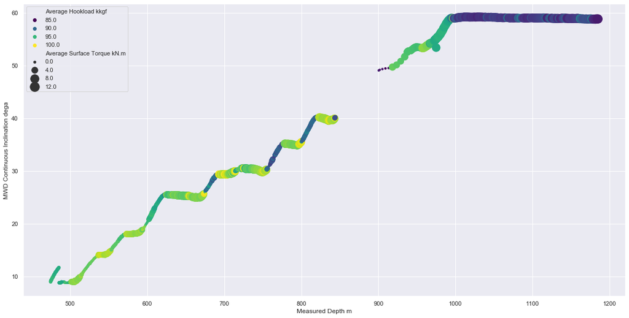

```python
df = df[np.isfinite(df['Measured Depth m'])]
df = df[np.isfinite(df['MWD Continuous Inclination dega'])]


plt.figure(figsize=(20,10))
sns.scatterplot(df['Measured Depth m'], df['MWD Continuous Inclination dega'],
                linewidth=0,
                hue=df['Average Hookload kkgf'],
                hue_norm=(85,100),
                palette="viridis",
                size=df['Average Surface Torque kN.m'],
                size_norm=(0,10),
                sizes=(20,300)
                )
```

Utilize the .describe() function to gauge the normalization range

```python
df['Average Hookload kkgf'].describe()
```

```
count    1963.000000
mean       94.636537
std         3.698203
min        71.966965
25%        91.820703
50%        96.034577
75%        97.359066
max       104.303565
Name: Average Hookload kkgf, dtype: float64
```

Simple plot is also useful to understand the data contents, such as outliers.

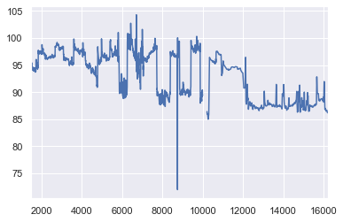

```python
df['Average Hookload kkgf'].plot()
```

## Color palettes

While in publication grayscale is typically preferred, when using color use good color schemes. Examples below are good - the brightness of colors is consistent with color scale.

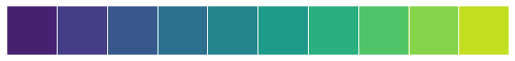

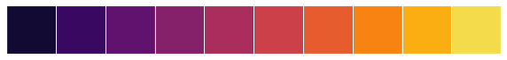

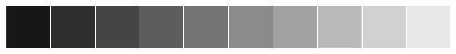

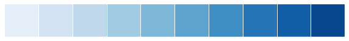

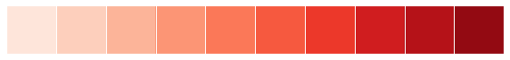

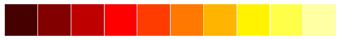

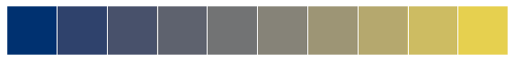

```python
palettes = ['viridis','inferno', 'gray', 'Blues', 'Reds', 'hot', 'cividis']
for i in palettes:
    sns.palplot(sns.color_palette(i,10))
```

Divergin palletes are also possible to highlight that something is below or above a certain level (like a physical map)

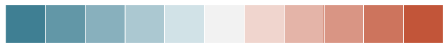

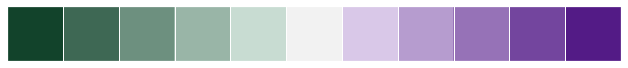

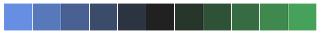

```python
sns.palplot(sns.diverging_palette(220, 20, n=11))
sns.palplot(sns.diverging_palette(145, 280, s=85, l=25, n=11))
sns.palplot(sns.diverging_palette(255, 133, l=60, n=11, center="dark"))
```

#### Avoid "jet" palette

A ~rainbow pallete that is the most commonly used despite being a poor in representing data

[figure not shown]

https://jakevdp.github.io/blog/2014/10/16/how-bad-is-your-colormap/

https://pdfs.semanticscholar.org/ee79/2edccb2c88e927c81285344d2d88babfb86f.pdf

Seaborn will straight out refuse to use it returning **ValueError: *No.***

```python
#palettes = ['jet']
#for i in palettes:
#    sns.palplot(sns.color_palette(i))
```

Jet colormap will be even more confusing when converted to grayscale.

Don't worry about the code below, it is there just to generate the chart.

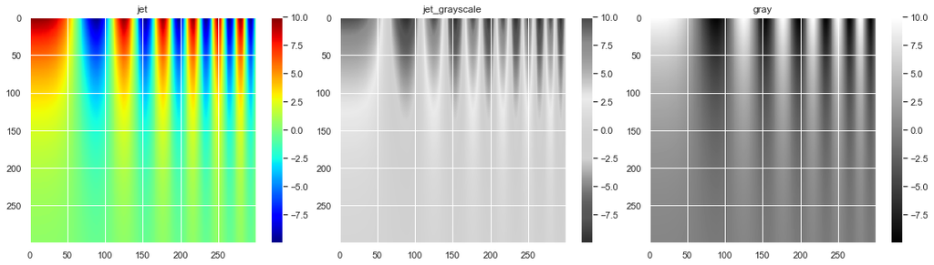

```python
def grayify_cmap(cmap):
    """Return a grayscale version of the colormap"""
    cmap = plt.cm.get_cmap(cmap)
    colors = cmap(np.arange(cmap.N))

    # convert RGBA to perceived greyscale luminance
    # cf. http://alienryderflex.com/hsp.html
    RGB_weight = [0.299, 0.587, 0.114]
    luminance = np.sqrt(np.dot(colors[:, :3] ** 2, RGB_weight))
    colors[:, :3] = luminance[:, np.newaxis]

    return cmap.from_list(cmap.name + "_grayscale", colors, cmap.N)



%matplotlib inline
import numpy as np
import matplotlib.pyplot as plt

x = np.linspace(0, 6,300)
y = np.linspace(0, 3,300)[:, np.newaxis]
z = 10 * np.cos(x ** 2) * np.exp(-y)
cmaps = [plt.cm.jet, grayify_cmap('jet'), plt.cm.gray]
fig, axes = plt.subplots(1, 3, figsize=(20, 5))
fig.subplots_adjust(wspace=0)

for cmap, ax in zip(cmaps, axes):
    im = ax.imshow(z, cmap=cmap)
    ax.set_title(cmap.name)
    fig.colorbar(im, ax=ax)
```

Use a palette that has lightness corresponding to value for better results

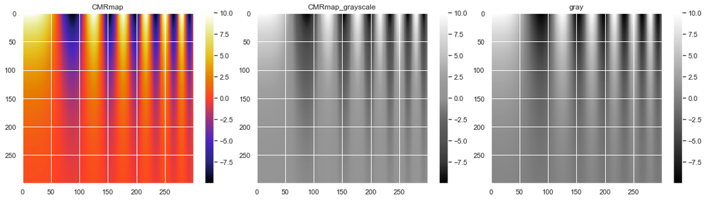

```python
cmaps = [plt.cm.CMRmap, grayify_cmap('CMRmap'), plt.cm.gray]
fig, axes = plt.subplots(1, 3, figsize=(20, 5))
fig.subplots_adjust(wspace=0)

for cmap, ax in zip(cmaps, axes):
    im = ax.imshow(z, cmap=cmap)
    ax.set_title(cmap.name)
    fig.colorbar(im, ax=ax)
```

## Regression

In Python we can easily perform regression using any function.

Let's assume we have a signal governed by an equation \begin{equation*} y = -0.2x^3 + 3x^2+30sin(x) \end{equation*}

This signal is noisy. Noise has a standard deviation of 30.

We have total 100 samples to work with, but 20 of them are outliers

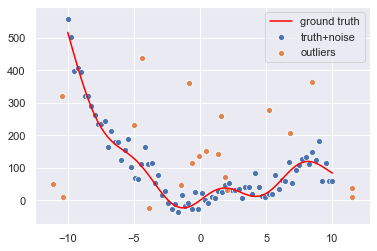

```python
np.random.seed(10) #fixed random seed, so you always get the same set of random numbers

n = 20 #outlier count
x_0 = np.linspace(-10,10,100-n)  #generate 100 minus n evenly spaced values from -10 to 10
y_0 = -0.2*x_0**3+3*x_0**2+30*np.sin(x_0) #calculate y

sns.lineplot(x_0,y_0,color="red", label="ground truth") #plot clean function

x = x_0  #keep x_0 separate for plotting later
y = y_0 + np.random.normal(0,30,100-n)  #generate new function - same as clean one plus noise with sd=30
sns.scatterplot(x,y,label="truth+noise") #plot the noisy chart

outliers_x = np.random.uniform(-12,12,n) #generate n outliers, x coordinates
outliers_y = np.random.uniform(-50,500,n)#... y coordinates
sns.scatterplot(outliers_x,outliers_y,label="outliers") #plot outliers only

x = np.concatenate([x, outliers_x]) #add the outliers to the x array
y = np.concatenate([y, outliers_y]) #add the outliers to the y array
```

Let's look at the raw data. You can see, that the data is very noisy and difficult to make a regression of!

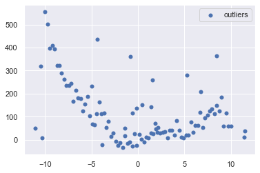

```python
sns.scatterplot(x,y,label="outliers",linewidth=0)
```

Let's assume that we know the function itself, but we do not know the parameters, effectively, known shape of the funtion is: \begin{equation*} y = a_0 x^3 + a_1 x^2+a_2sin(x) \end{equation*}

We define a function in a parametric way that is suitable for the algorithm that will come later.

```python
def fun(a, x, y):
    return a[0]*x**3+a[1]*x**2+a[2]*np.sin(x) - y
```

We can import an optimization function from SciPy based on least squares method

```python
from scipy.optimize import least_squares
```

Let's develop two models.

One is optimized for outliers, where they no longer carry such a heavy weight (typical issue with least squares method).

Second is a vanilla Least Squares method

```python
a0 = np.ones(3) #initiating the parameters with ones

model = least_squares(fun, a0, args=(x,y),loss='soft_l1') #the soft_l1 is the more lenient loss function

model2 = least_squares(fun, a0, args=(x,y))

print(model.x) #show the calculated parameters
```

```
[-0.20864698  2.95738833 31.35128843]
```

Model returned:

$a_0 = -0.20864698$ (originally $-0.2$)

$a_1 = 2.95738833$ (originally $3$)

$a_2 = 31.35128843$ (originally $30$)

Which is very close to original values. Let's inspect it graphically. The match is nearly perfect.

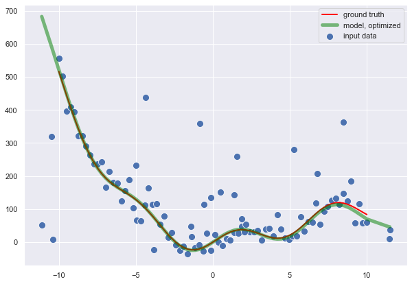

```python
plt.figure(figsize=(10,7)) #let's use slightly bigger chart
sns.scatterplot(x,y, label="input data",s=100)

sns.lineplot(x_0,y_0,color="red", lw=2,alpha=1,label="ground truth")

y2 = model.x[0]*x**3+model.x[1]*x**2+model.x[2]*np.sin(x) #calculate y based on the model
sns.lineplot(x, y2, color="green",lw=5,alpha=0.5, label="model, optimized")
```

In comparison, vanilla Least Square method did not perform so well:

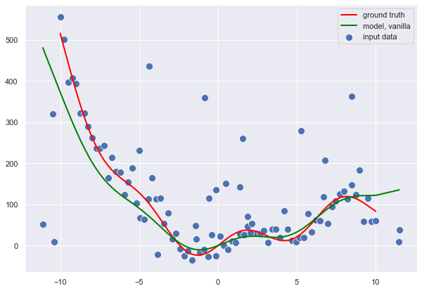

```python
plt.figure(figsize=(10,7))
sns.scatterplot(x,y, label="input data",s=100)

sns.lineplot(x_0,y_0,color="red", lw=2,alpha=1,label="ground truth")

y3 = model2.x[0]*x**3+model2.x[1]*x**2+model2.x[2]*np.sin(x)
sns.lineplot(x, y3, color="green",lw=2,dashes="-",alpha=1, label="model, vanilla")
```

Let's calculate $R^2$ values for both models.

Note: in this implementation $R^2$ value can be negative

```python
from sklearn.metrics import r2_score

print(f'R^2 value for optimized fitting is: {r2_score(y,y2)}' )
print(f'R^2 value for standard fitting is : {r2_score(y,y3)}' )
```

```
R^2 value for optimized fitting is: 0.13286411606455029
R^2 value for standard fitting is : 0.2922538200391831
```

The objectively much better model has a lower $R^2$ value. As you can see, this is not the ultimate metric.

k means clustering

feature engineering

Correlation

Classification